# Untitled

Lam

2024-01-28

## Tổng quan dữ liệu hiện có

Để đánh giá được mối quan hệ giữa hai biến phân loại (categorical variables) trong một tập dữ liệu, sử dụng Kiểm định Chi bình phương. Do đó, xác định được các mối quan hệ có ý nghĩa thống kê giữa **“nhompolyp”** và **“Age, rightcolon, kichthuoclon, Paris, NBI”**

| **Characteristic** | **0**, N = 200<sup>1</sup> | **1**, N = 252<sup>1</sup> | **p-value**<sup>2</sup> |
| --- | --- | --- | --- |
| Age | 57.3 (14.2) | 61.2 (12.3) | 0.002 |
| Sex |  |  | 0.493 |
| 0 | 120 (60.0%) | 142 (56.3%) |  |
| 1 | 80 (40.0%) | 110 (43.7%) |  |
| TSUTDT |  |  | 0.978 |
| 0 | 182 (91.0%) | 228 (90.5%) |  |
| 1 | 18 (9.0%) | 24 (9.5%) |  |
| TSPDT | 55 (27.5%) | 71 (28.2%) | 0.958 |
| TSGD |  |  | 0.367 |
| 0 | 190 (95.0%) | 233 (92.5%) |  |
| 1 | 10 (5.0%) | 19 (7.5%) |  |
| HTL |  |  | 0.497 |
| 0 | 107 (53.5%) | 144 (57.1%) |  |
| 1 | 93 (46.5%) | 108 (42.9%) |  |
| Ruou |  |  | 0.217 |
| 0 | 109 (54.5%) | 153 (60.7%) |  |
| 1 | 91 (45.5%) | 99 (39.3%) |  |
| BMI | 23.2 (2.8) | 23.3 (2.9) | 0.477 |
| kichthuoclon |  |  | <0.001 |
| 0 | 188 (94.0%) | 198 (78.6%) |  |
| 1 | 12 (6.0%) | 54 (21.4%) |  |
| Paris |  |  | <0.001 |
| 0 | 157 (78.5%) | 126 (50.0%) |  |
| 1 | 43 (21.5%) | 126 (50.0%) |  |
| rightcolon |  |  | 0.043 |
| 0 | 130 (65.0%) | 139 (55.2%) |  |
| 1 | 70 (35.0%) | 113 (44.8%) |  |
| NBI |  |  | <0.001 |
| 0 | 173 (86.5%) | 42 (16.7%) |  |
| 1 | 27 (13.5%) | 210 (83.3%) |  |

<sup>1</sup> Mean (SD); n (%)  
<sup>2</sup> Welch Two Sample t-test; Pearson’s Chi-squared test

## Phân chia dữ liệu

Vì sự hạn chế của dữ liệu, nhằm xác nhận lại mô hình được sử dụng, phân chia tập dữ liệu thành 2 nhóm với nhóm train (70%) và nhóm validation/test (30%). Sử dụng set.seed(123) để chọn cố định sự ngẫu nhiên.

```r
set.seed(123)
dfsplit <- initial_split(df, prop = 0.7)
train <- training(dfsplit)
test  <- testing(dfsplit)
```

## Vẽ đường cong ROC

Đường cong ROC được sử dụng để mô tả mối liên hệ giữa độ nhạy và độ đặc hiệu.

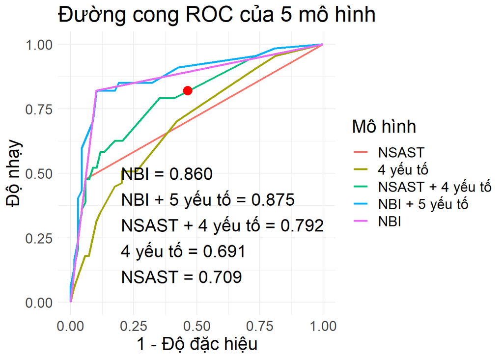

Ý nghĩa của diện tích dưới đường cong (AUC): Nếu cả hai BN cùng được xét nghiệm bằng phương pháp NSAST + 4 yếu tố và AUC = 0.792 thì điều này có nghĩa là xác suất BN có bệnh có kết quả xét nghiệm với giá trị cao hơn BN không mắc bệnh là 79.2%.

## Độ nhạy - Độ đặc hiệu - Độ chính xác

**MODEL 1: WLE**

```
##           threshold  accuracy sensitivity specificity
## threshold 0.6660779 0.7111111   0.4776119   0.9411765
```

**MODEL 2: 4 factors**

```
##           threshold  accuracy sensitivity specificity
## threshold 0.6408403 0.6544118   0.5074627   0.7971014
```

**MODEL 3: WLE + 4 factors**

```
##           threshold  accuracy sensitivity specificity
## threshold 0.5901999 0.7333333   0.5820896   0.8823529
```

**MODEL 4: NBI + 5 factors**

```
##           threshold  accuracy sensitivity specificity
## threshold 0.6812954 0.8592593   0.8208955   0.8970588
```

**MODEL 5: NBI**

```
##           threshold  accuracy sensitivity specificity
## threshold 0.5492401 0.8602941   0.8208955   0.8985507
```

## Mô hình NSAST + 4 yếu tố

Diện tích dưới đường cong của mô hình và khoảng tin cậy 95%

```
## Area under the curve: 0.7923
```

```
## 95% CI: 0.7178-0.8667 (DeLong)
```

Tóm tắt mô hình NSAST + 4 yếu tố

```
##
## Call:
## glm(formula = nhompolyp ~ WLE + Tuoicao + Paris + kichthuoclon +
##     rightcolon, family = "binomial", data = train)
##
## Deviance Residuals:
##     Min       1Q   Median       3Q      Max
## -2.6656  -0.9431   0.3370   0.9807   1.6614
##
## Coefficients:
##               Estimate Std. Error z value Pr(>|z|)
## (Intercept)    -1.0905     0.3163  -3.448 0.000566 ***
## WLE1            2.3580     0.3917   6.019 1.75e-09 ***
## Tuoicao1        0.5108     0.3208   1.592 0.111296
## Paris1          0.6569     0.3182   2.065 0.038951 *
## kichthuoclon1   0.6835     0.5271   1.297 0.194741
## rightcolon1     0.4048     0.2724   1.486 0.137205
## ---
## Signif. codes:  0 '***' 0.001 '**' 0.01 '*' 0.05 '.' 0.1 ' ' 1
##
## (Dispersion parameter for binomial family taken to be 1)
##
##     Null deviance: 428.80  on 315  degrees of freedom
## Residual deviance: 331.89  on 310  degrees of freedom
## AIC: 343.89
##
## Number of Fisher Scoring iterations: 5
```

## Điểm cut-off của mô hình NSAST + 4 yếu tố

Chức năng coords “youden” biểu diễn cho giá trị Youden’s J statistic. Điểm cut-off tối ưu là ngưỡng mà tại đó tối đa khoảng cách từ đường cong đến đường chéo (hay còn gọi là điểm Youden).

Công thức: $max(sensitivities + specificities - 1)$

```
## [1] "Giá trị cut-off tối ưu trên ROC là 0.464"
```

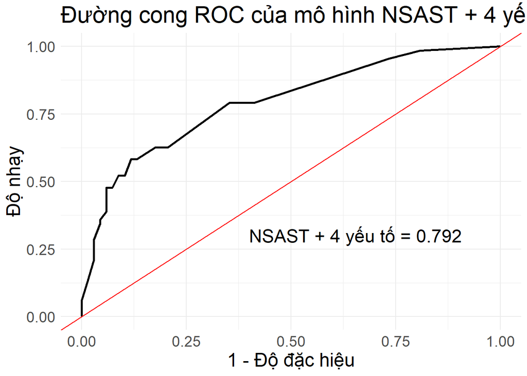

## Điểm C-index của mô hình

Trong phân loại nhị phân (ví dụ: dự đoán sự xuất hiện hoặc vắng mặt của bệnh), chỉ số C được sử dụng tương tự để đánh giá khả năng phân biệt giữa các trường hợp dương tính và âm tính của mô hình.

```
## [1] "Điểm C-index là 0.794"
```

## Điểm nguy cơ

Dựa vào intercept của mô hình, intercept của mỗi yếu tố sẽ chia cho yếu tố có intercept nhỏ nhất (rightcolon), sau đó khi mỗi yếu tố xuất hiện sẽ tăng lên số điểm tương ứng.

```
##   (Intercept)          WLE1      Tuoicao1        Paris1 kichthuoclon1
##            -3             6             1             2             2
##   rightcolon1
##             1
```

```
## [1] "Điểm 0 thì có nguy cơ p = 0.252"
## [1] "Điểm 1 thì có nguy cơ p = 0.335"
## [1] "Điểm 2 thì có nguy cơ p = 0.430"
## [1] "Điểm 3 thì có nguy cơ p = 0.531"
## [1] "Điểm 4 thì có nguy cơ p = 0.629"
## [1] "Điểm 5 thì có nguy cơ p = 0.718"
## [1] "Điểm 6 thì có nguy cơ p = 0.792"
## [1] "Điểm 7 thì có nguy cơ p = 0.851"
## [1] "Điểm 8 thì có nguy cơ p = 0.895"
## [1] "Điểm 9 thì có nguy cơ p = 0.928"
## [1] "Điểm 10 thì có nguy cơ p = 0.951"
## [1] "Điểm 11 thì có nguy cơ p = 0.967"
## [1] "Điểm 12 thì có nguy cơ p = 0.977"
## [1] "Điểm 13 thì có nguy cơ p = 0.985"
## [1] "Điểm 14 thì có nguy cơ p = 0.990"
## [1] "Điểm 15 thì có nguy cơ p = 0.993"
## [1] "Điểm 16 thì có nguy cơ p = 0.995"
## [1] "Điểm 17 thì có nguy cơ p = 0.997"
```

## Biểu đồ nomogram

Biểu đồ nomogram là biểu đồ thường được sử dụng để dự đoán xác suất của một sự kiện cụ thể dựa trên nhiều biến độc lập theo cách đơn giản và trực quan hóa (tìm đọc thêm về nomogram tại [đây](https://www.ncbi.nlm.nih.gov/pmc/articles/PMC8040180/)). Dựa vào mô hình NSAST + 4 yếu tố, nghiên cứu tiến hành trực quan hóa về xác suất xảy ra của biến phụ thuộc “nhompolyp”. Với mỗi một yếu tố xuất hiện sẽ có một mốc điểm và khi cộng tổng số điểm của tất cả yếu tố xuất hiện sẽ so sánh khả năng xảy ra polyp.

```
##            nhompolyp                  WLE              Tuoicao
##         "Loại Polyp" "Dự đoán trên NSAST"               "Tuổi"
##                Paris         kichthuoclon           rightcolon
##  "Hình dạng đại thể"         "Kích thước"             "Vị trí"
```

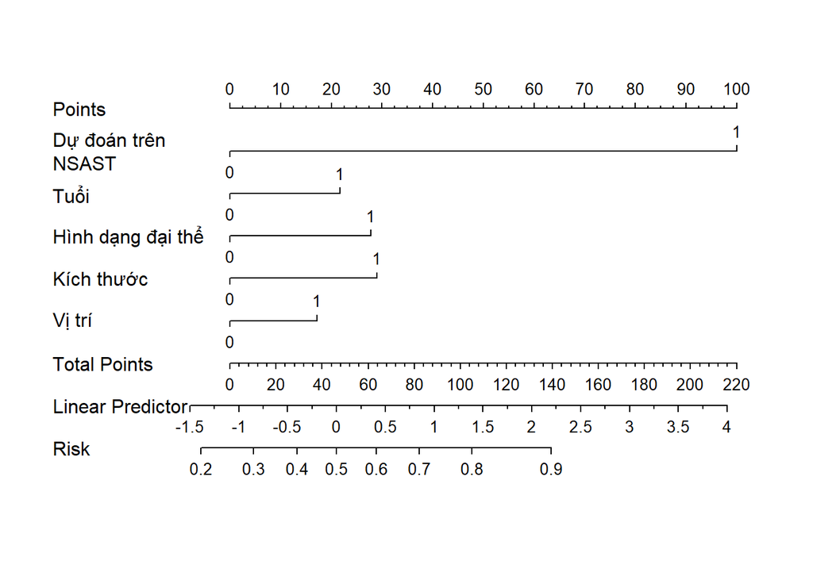

## Biểu đồ tỷ số số chênh

Tỷ số số chênh (OR) là một thước đo thống kê được sử dụng trong bối cảnh kết quả nhị phân để định lượng mức độ và hướng của mối liên hệ giữa hai biến.

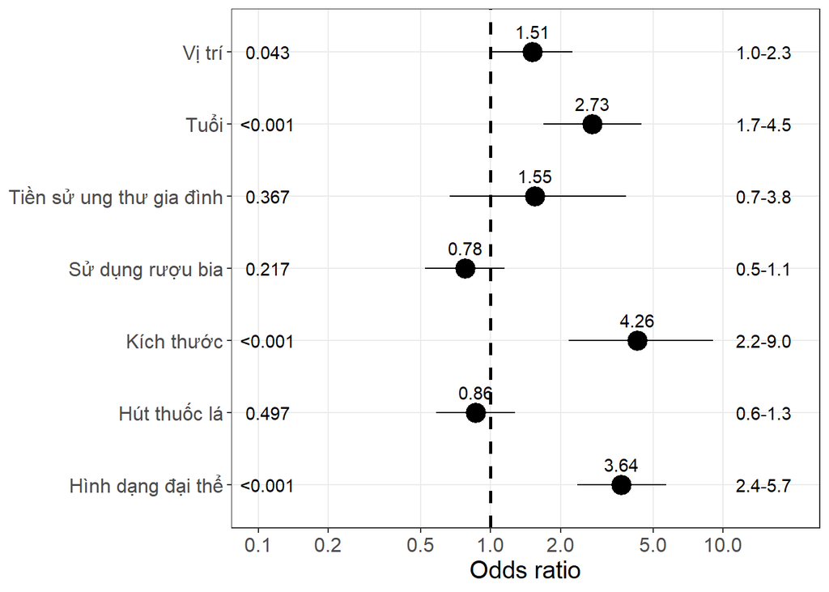

## Biểu đồ hiệu chuẩn

Biểu đồ hiệu chuẩn là một biểu đồ được sử dụng để đánh giá mức độ phù hợp của xác suất ước tính của mô hình dự đoán với kết quả quan sát thực tế. Trong bối cảnh phân loại nhị phân hoặc dự đoán xác suất, việc hiệu chỉnh là cần thiết để đảm bảo rằng xác suất dự đoán phản ánh chính xác khả năng xảy ra sự kiện quan tâm.

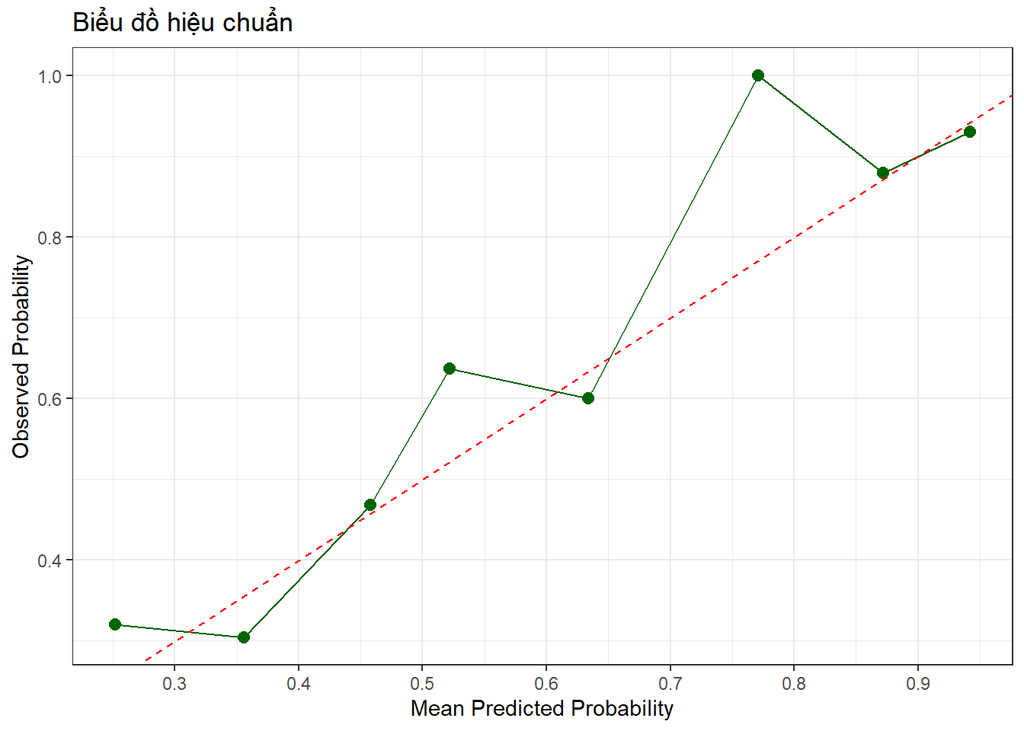

## Phân tích đường cong quyết định DCA

Phân tích đường cong quyết định (DCA) là một phương pháp thống kê được sử dụng để đánh giá tính hữu ích hoặc tiện ích lâm sàng của mô hình dự đoán. Nó thường được sử dụng trong nghiên cứu y tế và chăm sóc sức khỏe để đánh giá giá trị của một mô hình trong việc hướng dẫn việc ra quyết định so với các chiến lược thay thế, ví dụ như điều trị cho tất cả bệnh nhân hoặc không điều trị gì.

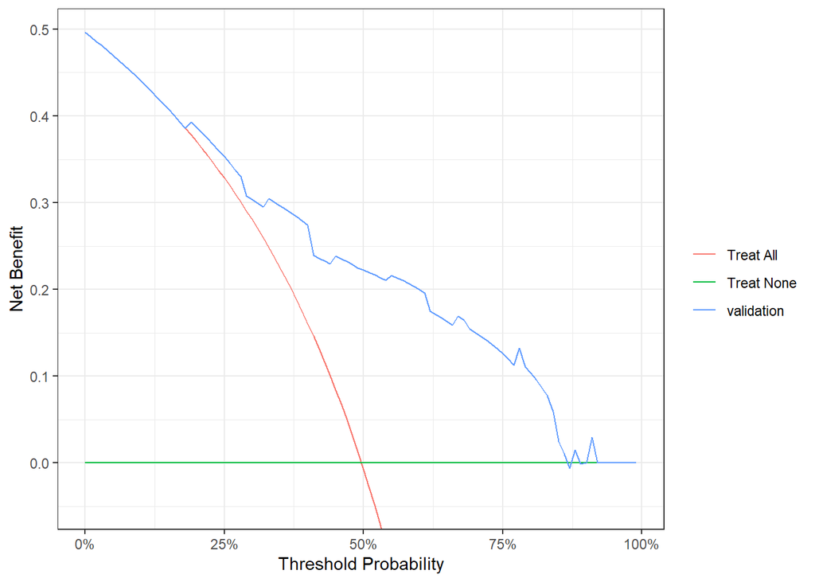

Decision Curve Analysis for Validation Group

```r
plot(dcurve)
```

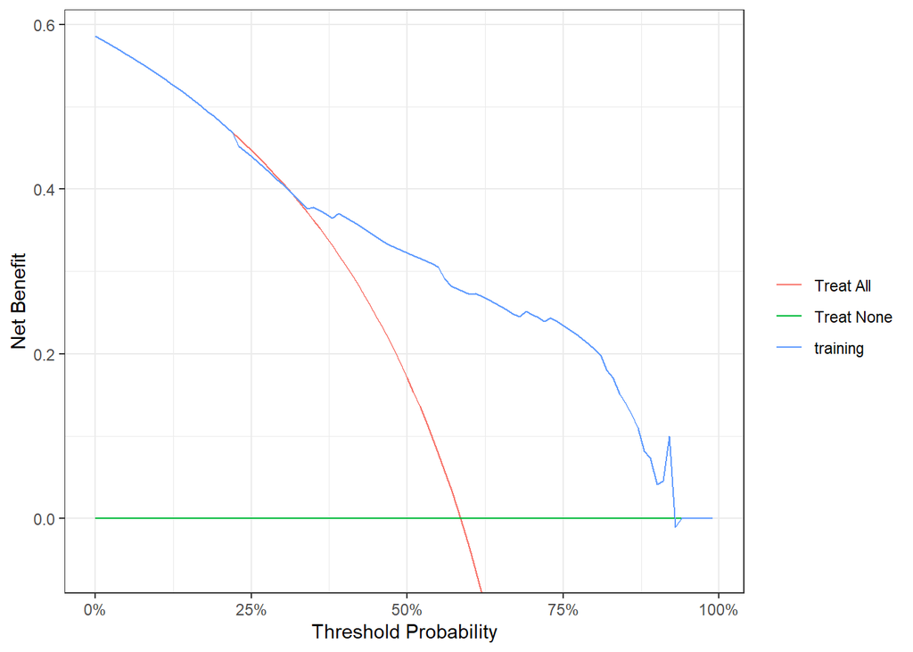

Decision Curve Analysis for Training Group

```r
plot(dcurve1)
```